# Chess Games Exploration

## Preliminary Wrangling

> This is an exploratory anlaysis of a dataset containing informations about **over 20,000 games** collected from a selection of users on the site **[Lichess](https://www.lichess.org)**.

```python
# import all packages and set plots to be embedded inline
import numpy as np
import pandas as pd
import matplotlib.pyplot as plt
import seaborn as sb
from matplotlib import rcParams

%matplotlib inline
%config InlineBackend.figure_format = 'retina'
rcParams['figure.figsize'] = 10,6
base_color = sb.color_palette()[0]
```

```python
# loading data into a pandas dataframe
games = pd.read_csv("games-mod.csv")
```

```python
# overview of data
print(games.shape)
print(games.dtypes)
print(games.head(10))
```

```
(20058, 9)
rated               bool
turns              int64
victory_status    object
winner            object
base_time          int64
increment          int64
white_rating       int64
black_rating       int64
opening_eco       object
dtype: object
   rated  turns victory_status winner  base_time  increment  white_rating  \
0  False     13      outoftime  white         15          2          1500
1   True     16         resign  black          5         10          1322
2   True     61           mate  white          5         10          1496
3   True     61           mate  white         20          0          1439
4   True     95           mate  white         30          3          1523
5  False      5           draw   draw         10          0          1250
6   True     33         resign  white         10          0          1520
7  False      9         resign  black         15         30          1413
8   True     66         resign  black         15          0          1439
9   True    119           mate  white         10          0          1381

   black_rating opening_eco
0          1191         D10
1          1261         B00
2          1500         C20
3          1454         D02
4          1469         C41
5          1002         B27
6          1423         D00
7          2108         B00
8          1392         C50
9          1209         B01
```

```python
# overview of dataset (cont.)
games.info()
```

```
<class 'pandas.core.frame.DataFrame'>
RangeIndex: 20058 entries, 0 to 20057
Data columns (total 9 columns):
 #   Column          Non-Null Count  Dtype
---  ------          --------------  -----
 0   rated           20058 non-null  bool
 1   turns           20058 non-null  int64
 2   victory_status  20058 non-null  object
 3   winner          20058 non-null  object
 4   base_time       20058 non-null  int64
 5   increment       20058 non-null  int64
 6   white_rating    20058 non-null  int64
 7   black_rating    20058 non-null  int64
 8   opening_eco     20058 non-null  object
dtypes: bool(1), int64(5), object(3)
memory usage: 1.2+ MB
```

```python
# overview of dataset (cont.)
games.describe()
```

|  | turns | base_time | increment | white_rating | black_rating |
| --- | --- | --- | --- | --- | --- |
| count | 20058.000000 | 20058.000000 | 20058.000000 | 20058.000000 | 20058.000000 |
| mean | 60.465999 | 13.824110 | 5.249626 | 1596.631868 | 1588.831987 |
| std | 33.570585 | 17.160179 | 14.289591 | 291.253376 | 291.036126 |
| min | 1.000000 | 0.000000 | 0.000000 | 784.000000 | 789.000000 |
| 25% | 37.000000 | 10.000000 | 0.000000 | 1398.000000 | 1391.000000 |
| 50% | 55.000000 | 10.000000 | 0.000000 | 1567.000000 | 1562.000000 |
| 75% | 79.000000 | 15.000000 | 7.000000 | 1793.000000 | 1784.000000 |
| max | 349.000000 | 180.000000 | 180.000000 | 2700.000000 | 2723.000000 |

According to [chess.com](https://support.chess.com/article/330-why-are-there-different-ratings-in-live-chess#:~:text=Live%20Chess%20has%20three%20different,games%2010%20minutes%20and%20longer.), live Chess has three different ratings based on different time controls:

- **Bullet rating** - For games under 3 minutes.
- **Blitz rating** - For games over 3 minutes but under 10 minutes.
- **Rapid rating** - For games 10 minutes and longer.

The system assumes an **average game-length of 40 moves** to estimate the total length of time available to each player; the result is what determines which rating is affected by a given time control

So, we can define a column **`game_rating`** that contains the ratings based on **`base_time`** (minutes) & **`increment`** (seconds) with estimated game-length of 40 moves.

$$ Estimated Game Time = BaseTime + \frac{Increment* 40}{60}$$

```python
# the equation for calculating estimated game time (rounding to nearest 0.5)
games['estimated_time'] = round((games.base_time + games.increment*40/60) * 2)/2

# initiate the game_rating column with the values of estimated time
games['game_rating'] = games['estimated_time']

# replacing estimated game time with associated game rating
games['game_rating'] = games['game_rating'].apply(lambda x : 'bullet' if x<3
                                                  else ('blitz' if x<10 else 'rapid'))
```

```python
# converting game_rating data type to ordered categorical data type
ratings = ['bullet', 'blitz', 'rapid']
ratings_cat = pd.api.types.CategoricalDtype(categories= ratings, ordered=True)
games['game_rating'] = games['game_rating'].astype(ratings_cat)
```

Now, we have columns for estimated game time and game rating. We don't need time control columns anymore.

```python
# dropping columns
games.drop(columns=['base_time', 'increment'], inplace = True)
```

```python
# final overview of dataset
print(games.shape)
print(games.dtypes)
games.head(15)
```

```
(20058, 9)
rated                 bool
turns                int64
victory_status      object
winner              object
white_rating         int64
black_rating         int64
opening_eco         object
estimated_time     float64
game_rating       category
dtype: object
```

|  | rated | turns | victory_status | winner | white_rating | black_rating | opening_eco | estimated_time | game_rating |
| --- | --- | --- | --- | --- | --- | --- | --- | --- | --- |
| 0 | False | 13 | outoftime | white | 1500 | 1191 | D10 | 16.5 | rapid |
| 1 | True | 16 | resign | black | 1322 | 1261 | B00 | 11.5 | rapid |
| 2 | True | 61 | mate | white | 1496 | 1500 | C20 | 11.5 | rapid |
| 3 | True | 61 | mate | white | 1439 | 1454 | D02 | 20.0 | rapid |
| 4 | True | 95 | mate | white | 1523 | 1469 | C41 | 32.0 | rapid |
| 5 | False | 5 | draw | draw | 1250 | 1002 | B27 | 10.0 | rapid |
| 6 | True | 33 | resign | white | 1520 | 1423 | D00 | 10.0 | rapid |
| 7 | False | 9 | resign | black | 1413 | 2108 | B00 | 35.0 | rapid |
| 8 | True | 66 | resign | black | 1439 | 1392 | C50 | 15.0 | rapid |
| 9 | True | 119 | mate | white | 1381 | 1209 | B01 | 10.0 | rapid |
| 10 | False | 39 | mate | white | 1381 | 1272 | A00 | 60.0 | rapid |
| 11 | False | 38 | resign | black | 1381 | 1867 | C02 | 60.0 | rapid |
| 12 | False | 60 | resign | black | 1381 | 1936 | C00 | 31.5 | rapid |
| 13 | False | 31 | resign | black | 1381 | 1607 | C00 | 8.0 | blitz |
| 14 | False | 31 | mate | white | 1094 | 1141 | C50 | 25.0 | rapid |

### What is the structure of your dataset?

This is a part of a dataset that can be found [here](https://www.kaggle.com/datasnaek/chess) and it contains information about the most recent 20,000 games (at its time) played by the top 100 teams on [Lichess](https://www.lichess.org).

**rated** (T/F): If true it means that the game is rated and players' ratings increase or decrease depending on the final result.  
**turns**: Number of total turns until the game ends.  
**victory_status**: It is the game result; out of time, draw, resign and mate.  
**winner**: The winner of the game; player as black or as white.  
**white_rating**, **black_rating**: Players' ratings on Lichess.  
**opening_eco**: Standardised code for any given opening play, list [here](https://www.365chess.com/eco.php) and it is the opening made by the winner or player as white if the game ends with a draw.  
**estimated_time**: Estimated game time.  
**game_rating**: Based on time controls, there are three possible ratings; bullet, blitz, rapid.

### What is/are the main feature(s) of interest in your dataset?

I'm interested in what makes a player, as black or white, **win** the game and whether player as white always have the advantage or not. Also, it is interesting to know what are the attributes associated with each **final game result**.

### What features in the dataset do you think will help support your investigation into your feature(s) of interest?

I expect that factors like; rating difference between players, opening play, and whether the player plays as white or black, could have the most effect on the final result. It is also possible that different game ratings/types have significant effect as the players adaptation to each type could be different.

## Univariate Exploration

**1. Victory Status**

Let's start with one of the variables of most interest.

```
resign       11147
mate          6325
outoftime     1680
draw           906
Name: victory_status, dtype: int64
```

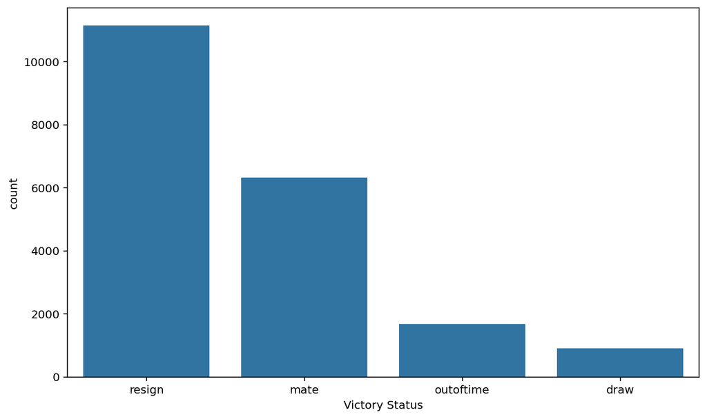

```python
# distribution of game status in a bar chart
status_order = games['victory_status'].value_counts().index
sb.countplot(data=games, x='victory_status', color=base_color, order=status_order);
plt.xlabel('Victory Status');
print(games['victory_status'].value_counts())
```

Resigning the game occurs the most, mate is the second most and much less occurances of out of time and draw games.

It is not unusual that most of the games end with one of the players resigning because those games are played by the top 100 teams in Lichess, so they figure out when they lose before it actually happens by calculating next possible moves.

> Since I'm interested in winnings and the factors affecting it ,whether it is a win through mate or the other player resigns, I will drop the rows of the two other results; draw and out of time.

```python
games = games.loc[(games['victory_status'].isin(['resign','mate']))]  # keep rows of winnings only
games.reset_index(drop=True, inplace=True)   # reseting index to fill gaps in the index
```

```python
# quick overview of dataset
print(games.shape)
print(games.describe())
```

```
(17472, 9)
              turns  white_rating  black_rating  estimated_time
count  17472.000000  17472.000000  17472.000000    17472.000000
mean      58.076522   1591.903446   1584.103365       17.348272
std       31.497095    288.750489    289.547309       22.767094
min        1.000000    784.000000    789.000000        7.500000
25%       36.000000   1393.000000   1387.000000       10.000000
50%       53.000000   1562.000000   1556.000000       10.500000
75%       75.000000   1786.000000   1777.000000       18.500000
max      222.000000   2700.000000   2621.000000      300.000000
```

**2. Rated?**

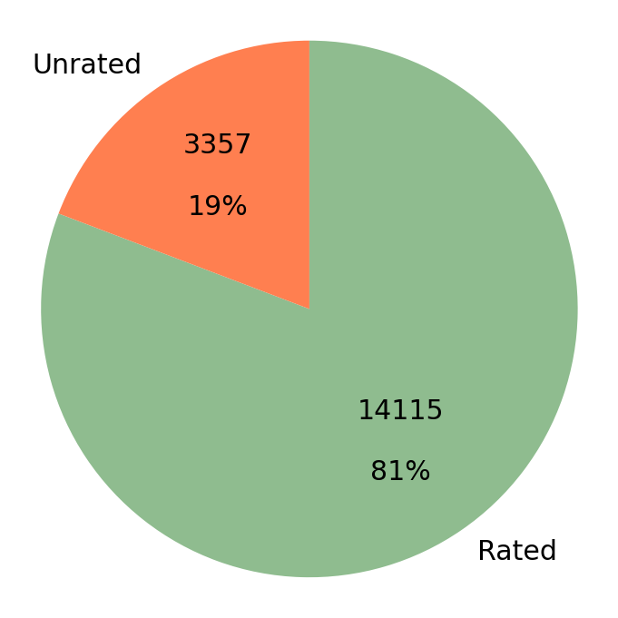

```python
# since there are only two possible values of 'rated' column, I'll invesigate them in a pie chart
rated_counts = games['rated'].apply(lambda x: 'Rated' if x==True else 'Unrated').value_counts()

def pie_values(pct):
    absolute = int(round(pct/100*games.shape[0],0))
    return "{}\n\n{:0.0f}%".format(absolute,pct)
def pie_abs(pct):
    absolute = int(round(pct/100*games.shape[0],0))
    return "{}".format(absolute)

plt.pie(data=games, x= rated_counts, labels= rated_counts.index,
        startangle=90, counterclock=False,autopct=pie_values, textprops=dict(fontsize=15),
        colors=['darkseagreen','coral'])
plt.axis('square');
```

Most of the games in the dataset are rated meaning that players ratings get affected by the result of the game which makes them competative games. In the other hand, unrated games are much less as they are played for practice or for fun.

A lot of factors affecting game result are to be investigated, so it might be a good idea to consider only rated games as they are meant to be competative and each player is motivated to win.

```python
games = games[games['rated']==True] # keeping rated games only and dropping unrated games

games.drop(columns='rated', axis=1, inplace= True) # dropping 'rated' column as it contains a single value

games.reset_index(drop=True, inplace=True)   # reseting index to fill gaps in the index
```

```python
# overview of dataset
print('Number of rows = {:,.0f} rows'.format(games.shape[0]))
games.head()
```

```
Number of rows = 14,115 rows
```

|  | turns | victory_status | winner | white_rating | black_rating | opening_eco | estimated_time | game_rating |
| --- | --- | --- | --- | --- | --- | --- | --- | --- |
| 0 | 16 | resign | black | 1322 | 1261 | B00 | 11.5 | rapid |
| 1 | 61 | mate | white | 1496 | 1500 | C20 | 11.5 | rapid |
| 2 | 61 | mate | white | 1439 | 1454 | D02 | 20.0 | rapid |
| 3 | 95 | mate | white | 1523 | 1469 | C41 | 32.0 | rapid |
| 4 | 33 | resign | white | 1520 | 1423 | D00 | 10.0 | rapid |

Now we have 14,115 rated games with a winner in each.

**3. Winner**

```
white    7410
black    6705
Name: winner, dtype: int64
```

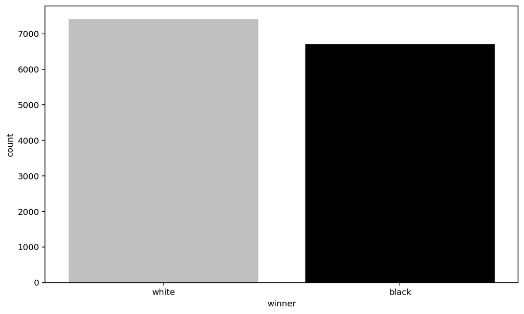

```python
# plotting bar chart for the distribution of the winners; white and black
sb.countplot(data=games, x='winner', palette=['silver','black'], order=['white','black']);
games.winner.value_counts()
```

Player as white has slightly more wins than player as black, but this doesn't conclude that white has an advantage over black.

**4. Game Rating/Category**

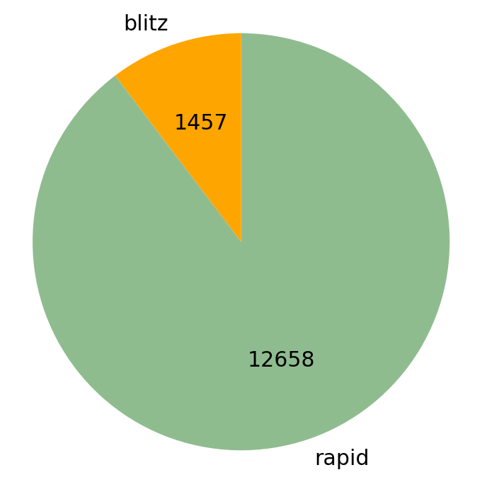

```python
# At most game_ratings column contains only 3 ratings; bullet, blitz, rapid. So, we can plot it as a pie chart.

# getting count for each rating and account for categories with zero count if any.
games['game_rating'] = games['game_rating'].cat.remove_unused_categories()
game_rating_count = games['game_rating'].value_counts()

# plotting pie chart
plt.pie(data=games, x= game_rating_count, labels= game_rating_count.index,
        startangle=90, counterclock=False,autopct=pie_abs, textprops=dict(fontsize=15),
        colors=['darkseagreen','orange'])
plt.axis('square');
```

It looks like there are no bullet rating games in this dataset. Most of games are of rapid ratings which are greater than or equal 10 minutes.

**5. Opening ECO**

```python
games['opening_eco'].nunique() # number of unique opening ECOs
```

```
341
```

There are 341 unique openings which makes them hard to investigate.

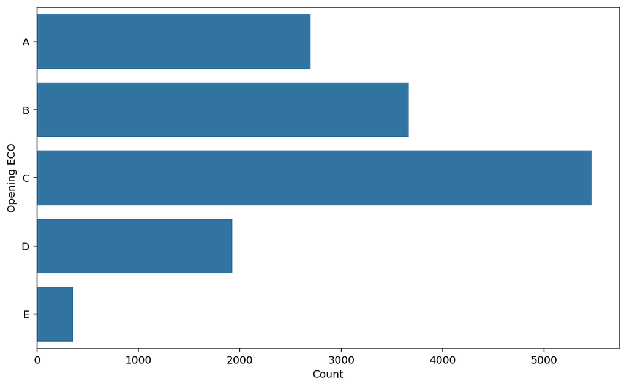

```python
# keeping volume labels and remove the rest of the codes
games['opening_eco']= games['opening_eco'].apply(lambda x: x[0])

# converting opening_eco data type to ordered categorical data type (alphabetically)
openings = ['A', 'B', 'C', 'D', 'E']
openings_cat = pd.api.types.CategoricalDtype(categories= openings, ordered=True)
games['opening_eco'] = games['opening_eco'].astype(openings_cat)


# plot
sb.countplot(data=games, y= 'opening_eco', color= base_color);
plt.ylabel('Opening ECO');
plt.xlabel('Count');
```

Openings in volume C are the most frequent followed by B and A. Volume D occurs much less and volume E openings are rarely used.

**6. Player Rating** *(White & Black)*

```python
games[['white_rating','black_rating']].describe()
```

|  | white_rating | black_rating |
| --- | --- | --- |
| count | 14115.000000 | 14115.000000 |
| mean | 1593.977471 | 1589.019270 |
| std | 282.705804 | 288.305857 |
| min | 784.000000 | 789.000000 |
| 25% | 1393.000000 | 1387.000000 |
| 50% | 1573.000000 | 1567.000000 |
| 75% | 1788.500000 | 1785.000000 |
| max | 2622.000000 | 2571.000000 |

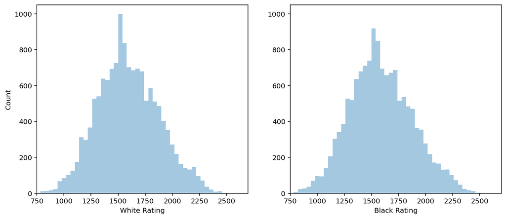

```python
# plotting white rating side by side with black rating

# constructing bins
step = 40
bins_rating = np.arange(780, 2700+step, step)

# plot white rating
plt.figure(figsize=(12,5))
plt.subplot(1,2,1)
sb.distplot(games['white_rating'],kde=False, bins= bins_rating);
plt.xlabel('White Rating')
plt.ylabel('Count')
plt.xlim(750,2700) # based on data min and max
plt.ylim(0,1050)

# plot black rating
plt.subplot(1,2,2)
sb.distplot(games['black_rating'],kde=False, bins=bins_rating);
plt.xlabel('Black Rating')
plt.xlim(750,2700) # based on data min and max
plt.ylim(0,1050); # to make y-axes synchronized
```

The two distributions are similar; they both have a slight right skew due to small number of GM (Grand Master) players who have the highest ratings.

However, I'm more interested in the difference of rating between the two players. Let's see the difference distribution.

**7. Rating Difference** *(White to Black)*

```python
# adding new column for difference in rating between white and black
games['rating_diff_wb'] = games['white_rating'] - games['black_rating']
games['rating_diff_wb'].describe()
```

```
count    14115.000000
mean         4.958200
std        223.197408
min      -1290.000000
25%       -100.000000
50%          3.000000
75%        112.000000
max       1056.000000
Name: rating_diff_wb, dtype: float64
```

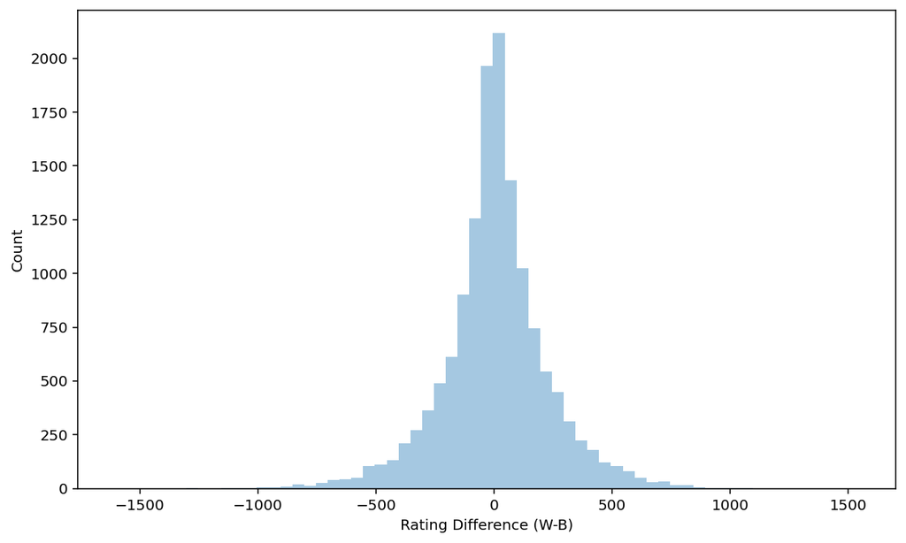

```python
# bins
bins_diff = np.arange(-1605, 1499+50, 50)

# plot
sb.distplot(games['rating_diff_wb'],kde=False, bins= bins_diff);
plt.xlabel('Rating Difference (W-B)');
plt.ylabel('Count');
```

Points at far ends could be considered outliers. Despite knowing that it is possible that in certain games there are high difference in ratings between the two players, those points shall be investigated further.

```python
# far points at the left end
left_end = -1000 # eyeballed
print('Number of far points at the left end= {}'.format(games[games['rating_diff_wb']<=left_end].shape[0]))
games[games['rating_diff_wb']<=left_end]
```

```
Number of far points at the left end= 6
```

|  | turns | victory_status | winner | white_rating | black_rating | opening_eco | estimated_time | game_rating | rating_diff_wb |
| --- | --- | --- | --- | --- | --- | --- | --- | --- | --- |
| 1922 | 52 | mate | black | 1212 | 2215 | E | 10.0 | rapid | -1003 |
| 2124 | 28 | mate | black | 1074 | 2151 | A | 10.0 | rapid | -1077 |
| 2892 | 8 | resign | black | 1157 | 2312 | B | 10.0 | rapid | -1155 |
| 6776 | 90 | mate | black | 1305 | 2318 | D | 8.0 | blitz | -1013 |
| 8094 | 22 | resign | black | 1015 | 2305 | B | 8.5 | blitz | -1290 |
| 8786 | 38 | mate | black | 1085 | 2171 | B | 10.0 | rapid | -1086 |

```python
# far points at the right end
right_end= 1000 # eyeballed
print('Number of far points at the left end= {}'.format(games[games['rating_diff_wb']>=right_end].shape[0]))
games[games['rating_diff_wb']>=right_end]
```

```
Number of far points at the left end= 3
```

|  | turns | victory_status | winner | white_rating | black_rating | opening_eco | estimated_time | game_rating | rating_diff_wb |
| --- | --- | --- | --- | --- | --- | --- | --- | --- | --- |
| 8484 | 49 | resign | white | 2191 | 1174 | C | 10.0 | rapid | 1017 |
| 10059 | 11 | resign | white | 2386 | 1330 | C | 10.0 | rapid | 1056 |
| 12562 | 23 | mate | white | 2123 | 1108 | A | 18.5 | rapid | 1015 |

There is nothing odd about those points, the ones with the higher ratings win in all of these games which makes sense, except the fact that they cause long tails in both sides of the difference distribution, so I decided to keep them.

**8. Number of Turns**

Number of turns may not be related to the variable of interest, winner,

```python
games['turns'].describe()
```

```
count    14115.000000
mean        59.317109
std         31.592751
min          1.000000
25%         38.000000
50%         55.000000
75%         76.000000
max        222.000000
Name: turns, dtype: float64
```

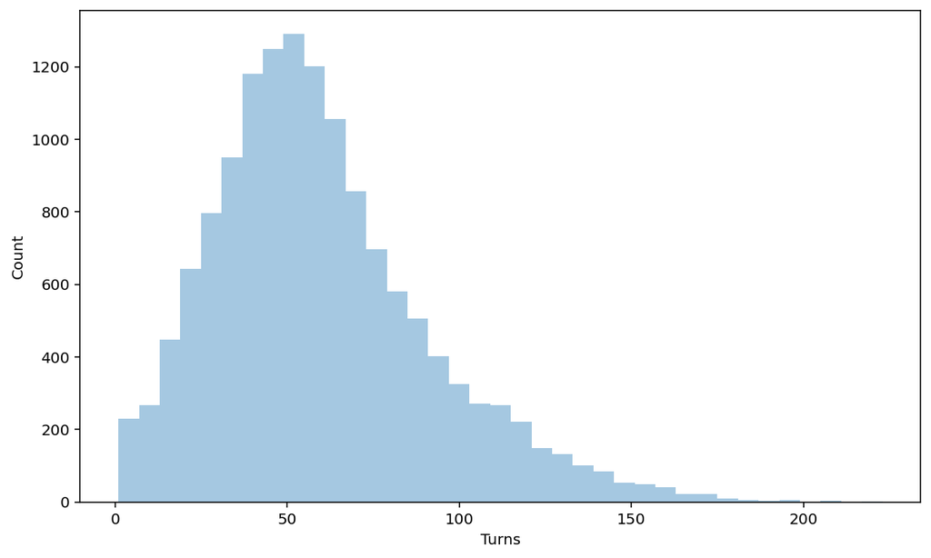

```python
# bin edges
step= 6
bins_turns = np.arange(games['turns'].min(), games['turns'].max()+step, step)

# plot
sb.distplot(games['turns'], kde=False, bins=bins_turns);
plt.xlabel('Turns')
plt.ylabel('Count');
```

The distribution of turns is right skewed with a long tail that suggests further investigation using log scale

```python
np.log10(games['turns'].describe())
```

```
count    4.149681
mean     1.773180
std      1.499587
min      0.000000
25%      1.579784
50%      1.740363
75%      1.880814
max      2.346353
Name: turns, dtype: float64
```

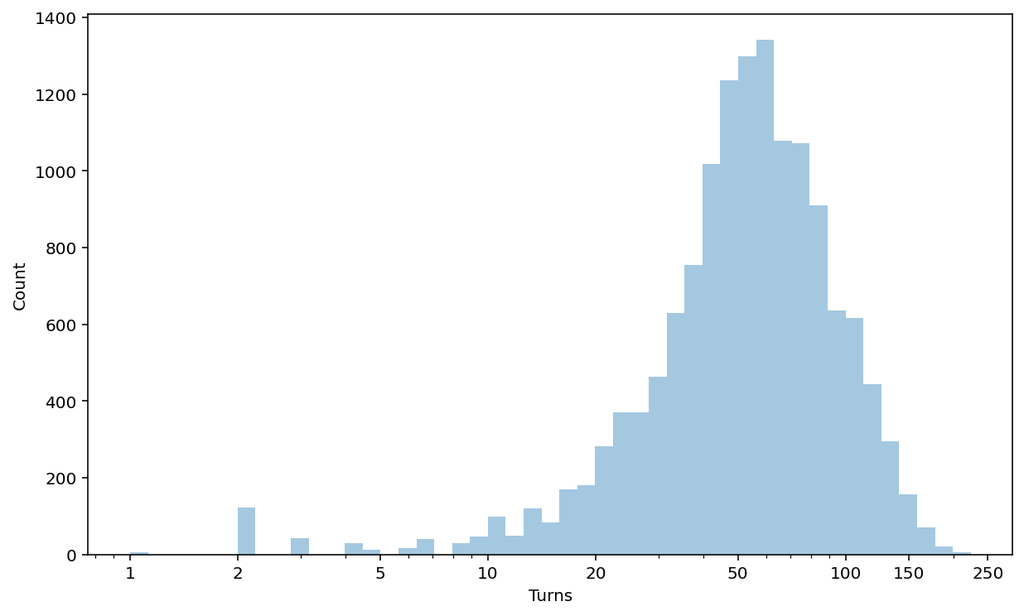

```python
# right skewed distribution with long tail suggests plotting the distribution with a log scale
step = 0.05
bins_log_turns = 10**np.arange(0,np.log10(games['turns'].max())+step, step)
sb.distplot(games['turns'], kde=False, bins= bins_log_turns);
plt.xscale('log')
ticks = [1, 2, 5, 10, 20, 50 ,100, 150, 250]
plt.xticks(ticks, ticks)
plt.xlabel('Turns')
plt.ylabel('Count');
```

The log scale exposes the obvious outliers at the left end which doesn't make sense in practice as it is hard for a game to be won by less than 4 turns. I looked it up myself in the games history at Lichess, and here is a rated rapid [game](https://lichess.org/V7a3QIoB/black#4) which is barely won in 4 turns.

```python
# investigating far points at the left

print(games[(games['turns']<4)].victory_status.value_counts()) # count number of points
games[(games['turns']<4)] # rows with less than 4 turns
```

```
resign    170
Name: victory_status, dtype: int64
```

|  | turns | victory_status | winner | white_rating | black_rating | opening_eco | estimated_time | game_rating | rating_diff_wb |
| --- | --- | --- | --- | --- | --- | --- | --- | --- | --- |
| 20 | 3 | resign | white | 1407 | 1500 | B | 12.5 | rapid | -93 |
| 97 | 2 | resign | black | 1443 | 1204 | B | 25.0 | rapid | 239 |
| 1332 | 1 | resign | black | 1464 | 1355 | A | 10.0 | rapid | 109 |
| 1345 | 2 | resign | black | 1055 | 1280 | A | 270.0 | rapid | -225 |
| 1355 | 2 | resign | white | 1765 | 1234 | A | 9.5 | blitz | 531 |
| ... | ... | ... | ... | ... | ... | ... | ... | ... | ... |
| 13490 | 2 | resign | black | 1445 | 1546 | A | 30.0 | rapid | -101 |
| 13491 | 2 | resign | white | 1538 | 1516 | B | 15.0 | rapid | 22 |
| 13492 | 3 | resign | black | 1630 | 1556 | A | 12.0 | rapid | 74 |
| 13493 | 2 | resign | white | 1834 | 1709 | C | 8.0 | blitz | 125 |
| 13639 | 2 | resign | black | 1728 | 2012 | B | 25.0 | rapid | -284 |

170 rows × 9 columns

There are 170 games in which one of the players resigned, and it is nearly impossible for the game to be finished in just 3 turns. It should be noted that it is an online game and there are many reasons for a player to resign a game and those reasons may mostly be unrelated to the game itself specially with such small number of turns. So those games are to be dropped from the dataset.

```python
# drop rows with number of turns < 4
games = games[(games['turns']>=4)]

games.reset_index(drop=True, inplace=True)   # reseting index to fill gaps in the index
```

Final distribution of number of turns:

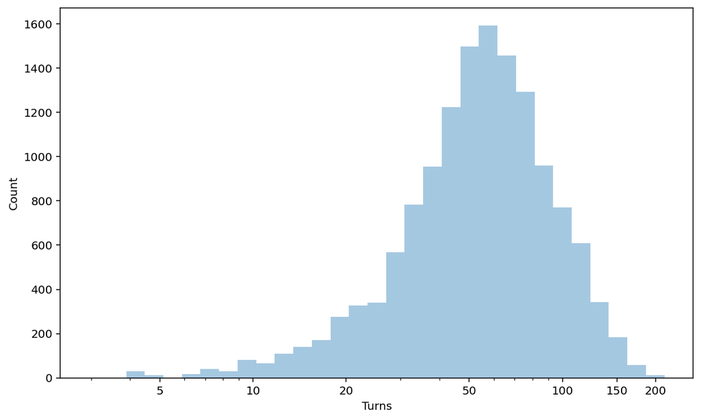

```python
# bins
step = 0.06
bins_log_turns = 10**np.arange(0.47,np.log10(games['turns'].max())+0.005, step)

# plot
sb.distplot(games['turns'], kde=False, bins= bins_log_turns);
plt.xscale('log')
ticks = [5, 10, 20, 50 ,100, 150, 200]
plt.xticks(ticks, ticks)
plt.xlabel('Turns')
plt.ylabel('Count');
```

Still left skewed distribution in log scale but with more resonable data points at both ends.

```python
print('Number of rows = {:,.0f} rows'.format(games.shape[0]))
```

```
Number of rows = 13,945 rows
```

### Discuss the distribution(s) of your variable(s) of interest. Were there any unusual points? Did you need to perform any transformations?

- **The game could end with 4 possible results and 2 of them are dropped because I'm more interested in the games that are won by checkmate or when one of players resign**. [Draw](https://www.chess.com/terms/draw-chess) is obviously not a win, and out of time result could end with a draw as the rules of the game states that if one player is out of time and the other player has insufficient material to checkmate the game ends with a draw.

### Of the features you investigated, were there any unusual distributions? Did you perform any operations on the data to tidy, adjust, or change the form of the data? If so, why did you do this?

- There are **rated and unrated games**, but I decided to investigate those rated games as they are more competative than unrated ones, and they form the majority of data. Then, this column becomes useless with one value so it is dropped.
- **Openings** in chess games are divided in **5 volumes** that are to be used instead of what is inside each voulume because it would be difficult to analyze all of them.
- **Players Ratings** on their own are not relevant but the difference between them is to be important in predicting the winner, or that is what I expect. So, **I added a column for the difference in ratings between white and black respectively**. Despite the long tailed distribution at both ends, which indicates high difference in rating, I decided not to remove those games as they are possible and there is nothing odd about their data.
- **Number of turns** may not be the best predictor of the game winner, but exploring it helped me find interesting points that needed further investigation. At first, the distribution was right skewed, so I applied **log scale** to take a good look at the right tail. Instead, the distribution shifted to the right and becomes left skewed. That is when I found **outliers at the left tail**; games with 1,2, and 3 turns only are odd in practice. After exploring those games, it is found that all of them ended with one of the players resigning which is not normal in a chess game after only 3 turns and it may be due to reasons unrelated to the game, so I decided to **drop those points**.

## Bivariate Exploration

First, let's start with one of the variables of interest: **winner**. I want to look at its relationship with game rating.

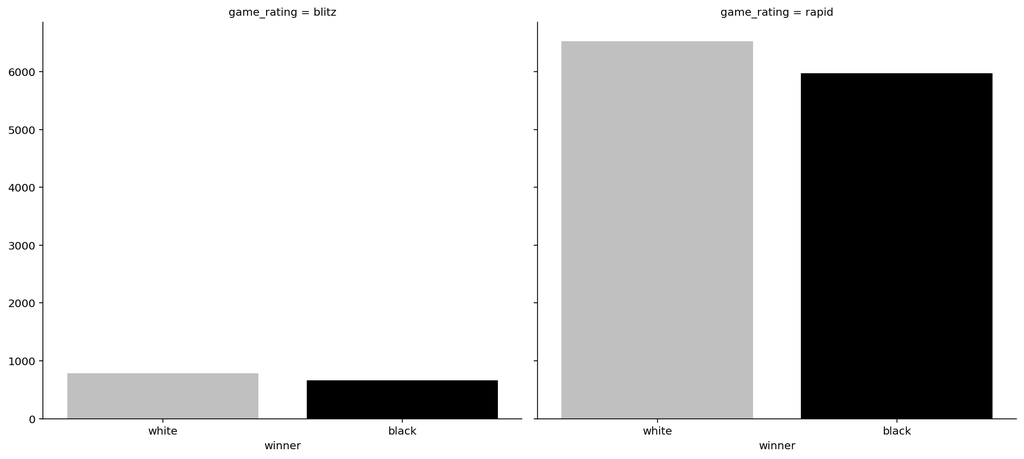

```python
# plot
g =sb.FacetGrid(data=games, col='game_rating', height=6, aspect=1.1)
g.map(sb.countplot, 'winner', order=['white', 'black'], palette=['silver','black']);
```

So, is the player with higher rating has more chances to win? To answer that, let's look at the relationship between rating difference and the winner.

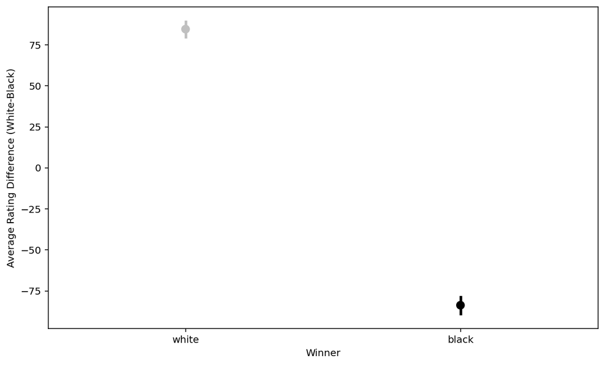

```python
# plot
sb.pointplot(data=games, x='winner', y= 'rating_diff_wb', order=['white', 'black'],palette=['silver','black'], linestyles="");
plt.ylabel('Average Rating Difference (White-Black)');
plt.xlabel('Winner');
```

As expected, the winner, player as white or as black, has an average difference in rating in his favor by about 80.

Are there certain opening groups associated with the winning player? Let's see.

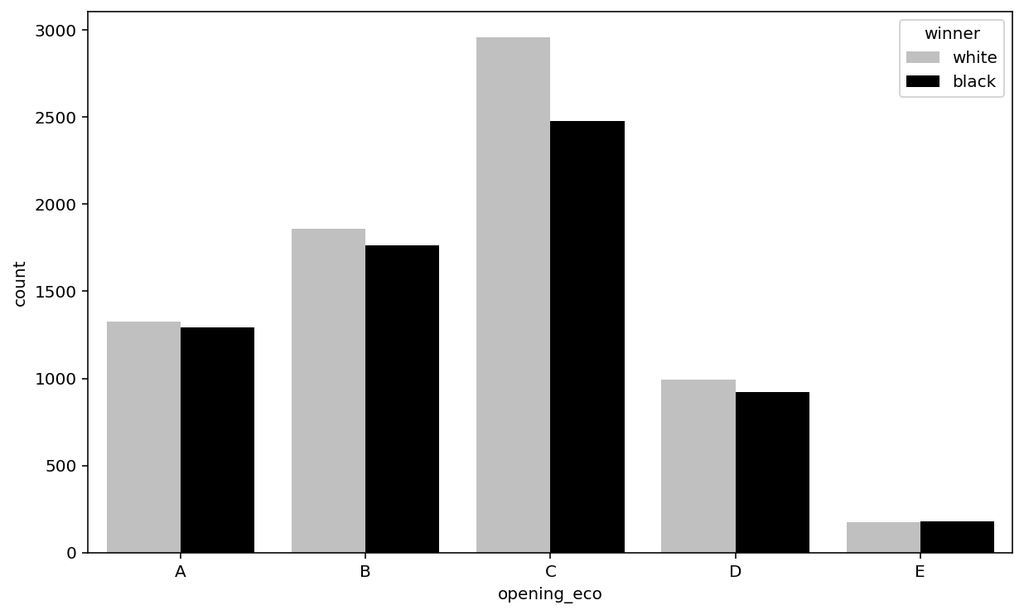

```python
sb.countplot(data=games, hue='winner', x='opening_eco', hue_order=['white','black'],palette=['silver','black']);
```

Openings of group C are used significantly more by the player as white to win the game compared to player as black while all other groups has very small difference in favor of player as white except for group E in which there is approximately no difference.

Do players as white need less number of turns to win a game?

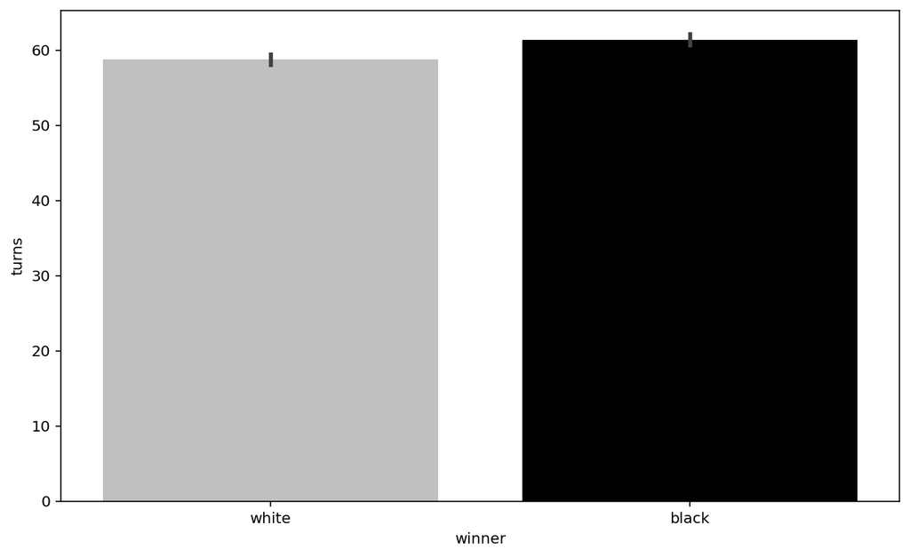

```python
# plotting winner againist average number of turns
sb.barplot(data=games, x='winner', y='turns', order=['white','black'], palette=['silver','black']);
```

On average, players as white need less number of turns to win the game. It might be a slight difference, but in chess game I'd argue that it is may be significant.

How the winner win the game?

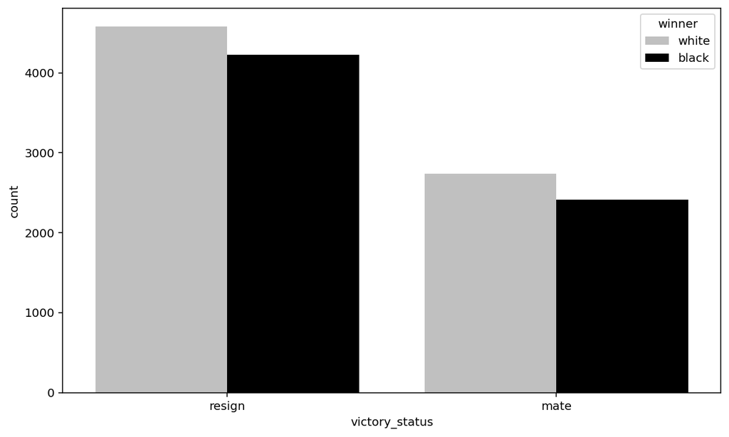

```python
# plotting the distribution of winners for each victory statusz
sb.countplot(data=games, hue='winner', x='victory_status', hue_order=['white','black'],palette=['silver','black']);
```

Most of the games are won when one of the players resigns,white or black. It could be because the games are played by high rated players who predicted the next moves and found out that they are losing before it happens.

So, let's move on to another variable of interest: **victory status**.

First, I need to take the absolute of rating difference because I want to look at its relationship with victory status regardless of the player ,black or white, who has the higher rating.

```python
# adding new column for absolute difference in rating
games['abs_rating_diff_wb'] = abs(games['white_rating'] - games['black_rating'])
```

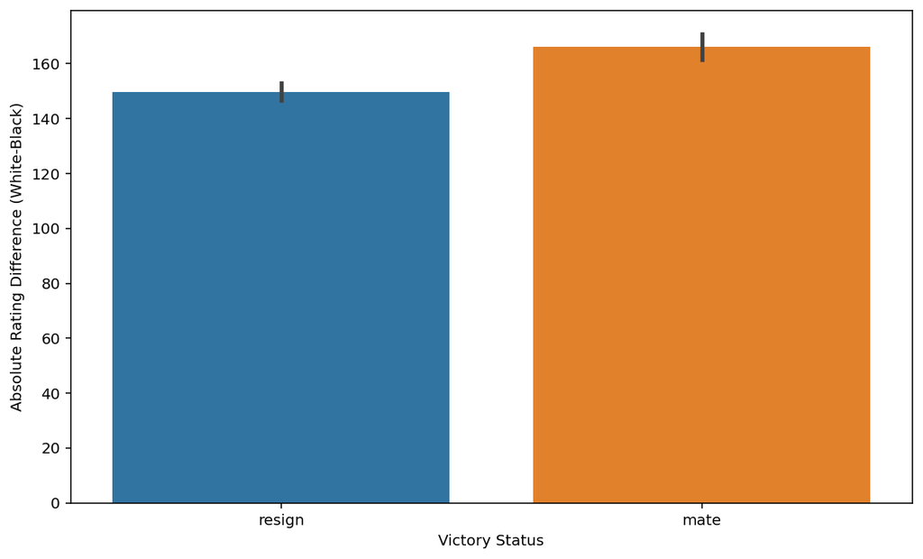

```python
# plotting (absolute rating difference) against (victory status)
sb.barplot(data= games, x='victory_status', y= 'abs_rating_diff_wb');
plt.ylabel('Absolute Rating Difference (White-Black)')
plt.xlabel('Victory Status');
```

Absolute rating difference, on average, is nearly the same for both game results, but the denisty of distribution of chekmates is slightly higher at bigger rating difference.

Looking at the relationship between victory status and the other variables:

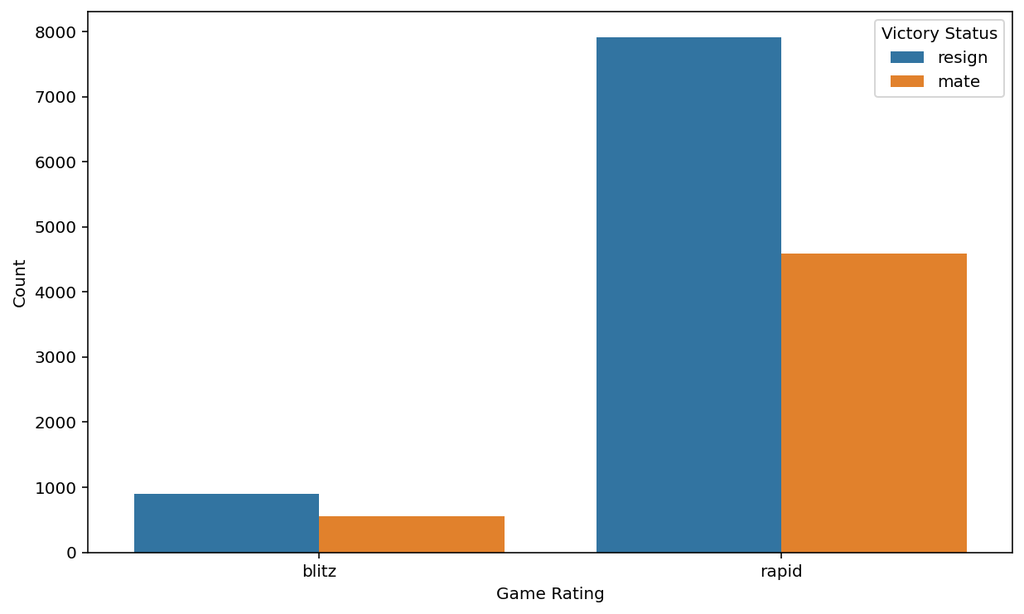

```python
# plotting victory status distribution for each game rating
sb.countplot(data=games, hue='victory_status', x='game_rating');
plt.ylabel('Count')
plt.xlabel('Game Rating')
plt.legend(title='Victory Status');
```

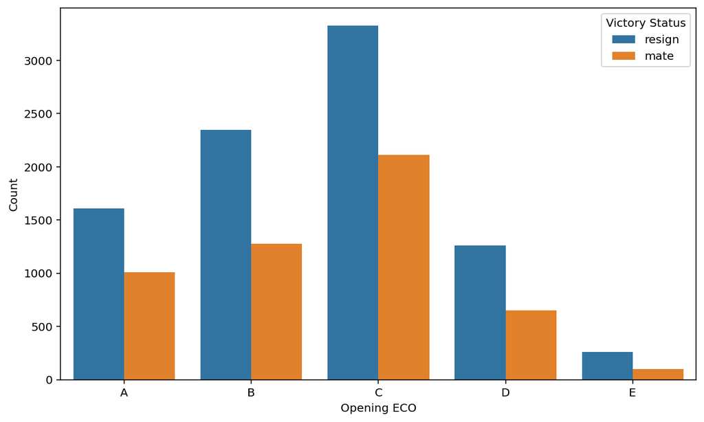

```python
# plotting victory status distribution for each opening
sb.countplot(data=games, hue='victory_status', x='opening_eco');
plt.ylabel('Count')
plt.xlabel('Opening ECO')
plt.legend(title='Victory Status');
```

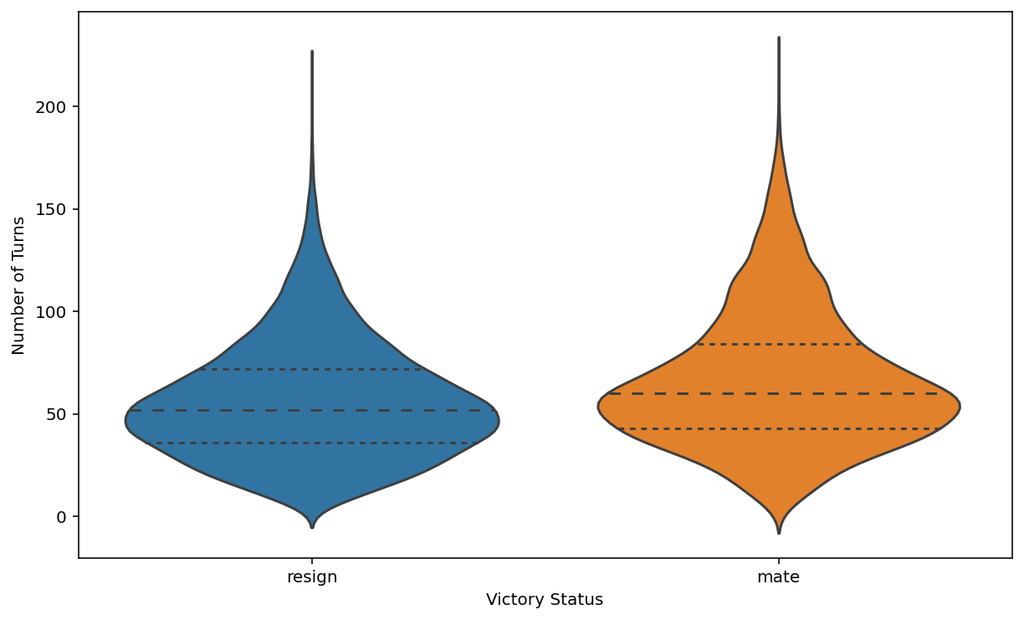

```python
# plotting victory status distribution for each opening
sb.violinplot(data=games, x='victory_status', y='turns', inner='quartile');
plt.ylabel('Number of Turns')
plt.xlabel('Victory Status');
```

- Both game ratings have similar trends for victory status.
- Haven't learnt much from the plot with groups of openings as each of these groups show the same trend of victory status.
- Winning by checkmates takes, on average, more number of turns than that of games won by resigning; it can be seen from the higher median and the thicker distribution at higher number of turns.

The above bivariate exploration is about the variables of interest; winner and victory status. Now, let's take a look at the other relationships that number of turns and rating difference have with the other variables. Starting with the relationship between them.

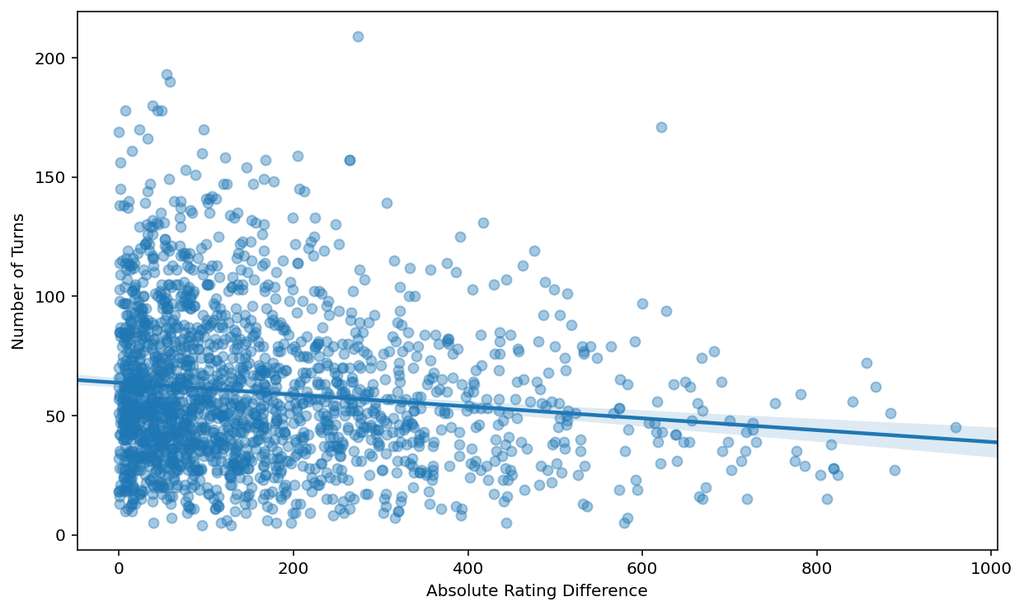

```python
# scatter plot between absolute rating difference and number of turns using a sample from the data
sb.regplot(data=games.sample(2000, replace=False), y='turns', x='abs_rating_diff_wb',
           fit_reg=True,truncate=False, scatter_kws={'alpha':0.4});
plt.xlabel('Absolute Rating Difference');
plt.ylabel('Number of Turns');
```

Number of turns has very weak correlation with the absolute rating difference. However, number of turns tends to be higher when the two players' ratings are so close (approximately zero difference between them).

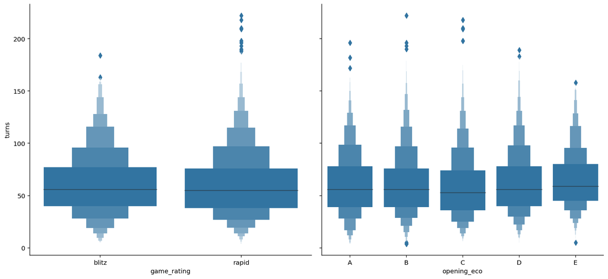

```python
# plotting number of turns against game rating and openings
g = sb.PairGrid(data = games, y_vars=['turns'],
            x_vars=['game_rating','opening_eco'], height=6, aspect=1.1,diag_sharey=True )
g.map(sb.boxenplot);
```

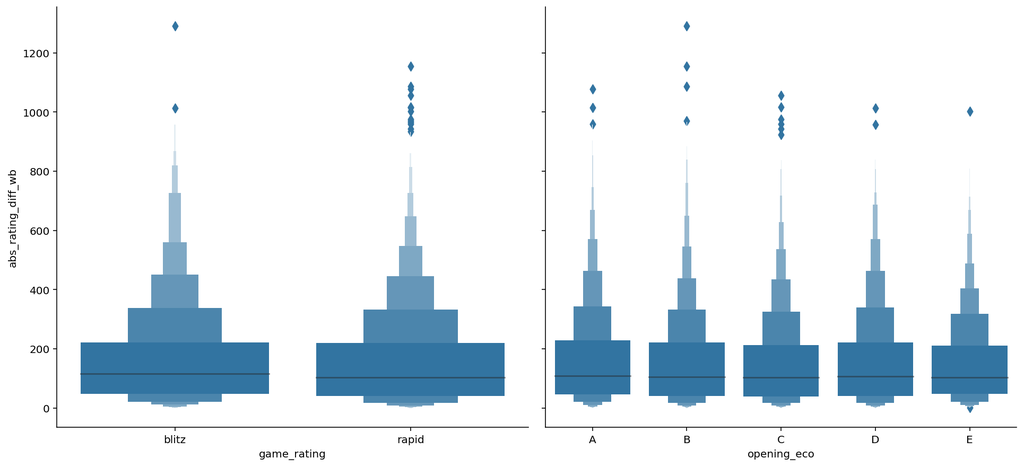

```python
# plotting absolute rating difference against game rating and openings
g = sb.PairGrid(data = games, y_vars=['abs_rating_diff_wb'],
            x_vars=['game_rating','opening_eco'], height=6, aspect=1.1,diag_sharey=True)
g.map(sb.boxenplot);
```

There is only one relationship left; game rating versus opening groups.

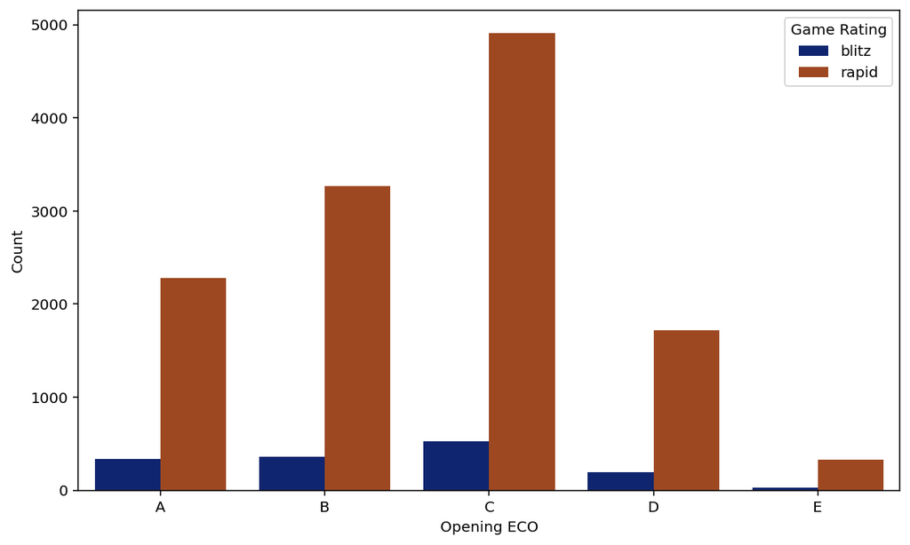

```python
#plot
sb.countplot(data=games, x='opening_eco', hue='game_rating', palette='dark');
plt.ylabel('Count')
plt.xlabel('Opening ECO')
plt.legend(title='Game Rating');
```

There is a small number of blitz games compared to rapid games that is why rapid rating dominates at each opening group.

After looking at each possible combination of variables, I want to look at the percentages of games won, instead of counts, for the variables of interest; winner and victory status.

I will get the percentage of games won by black and by white in each game rating then compare them.

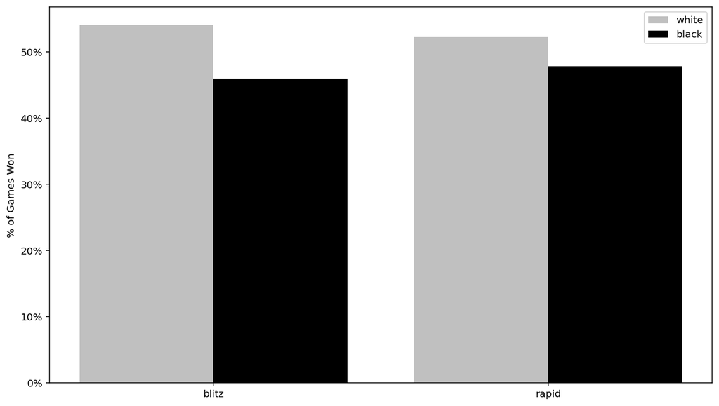

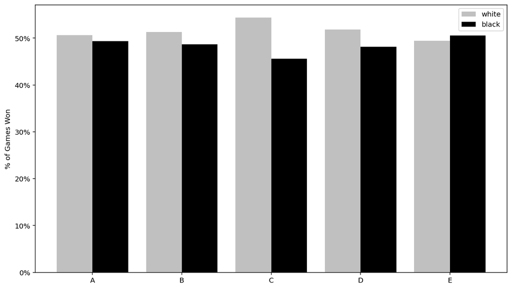

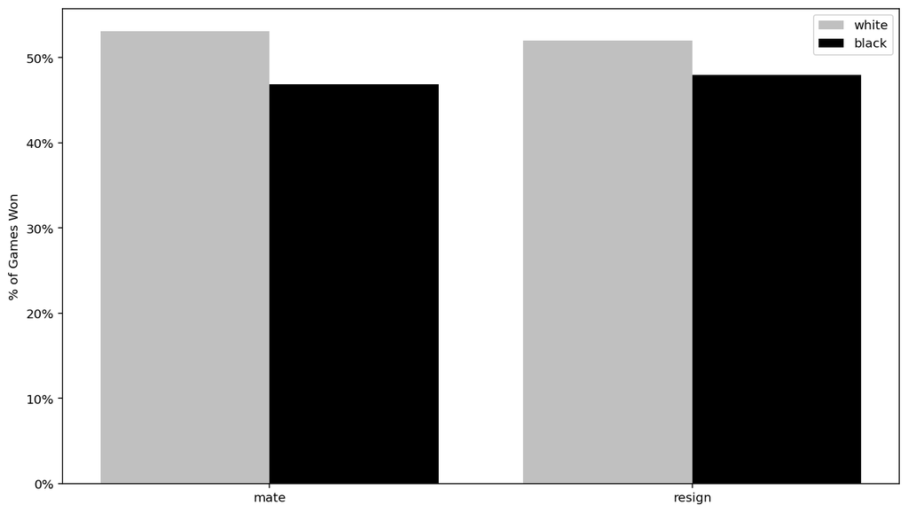

```python
def winner_percentages(var):
        ''' A function to plot the percentage of games won for each winner, white and black,
            and its variation with a variable
            var: (string) the variable you want to plot the variation with.
        '''
        white_counts = games.query('winner == "white"').groupby(var)[var].count()
        black_counts = games.query('winner == "black"').groupby(var)[var].count()
        game_var_counts = games[var].value_counts()

        white_var_pct= (white_counts/game_var_counts)*100
        black_var_pct= (black_counts/game_var_counts)*100
        plt.figure(figsize=(12,7))
        plt.bar(data= games, x=white_var_pct.index, height=white_var_pct,
                width=-0.4, align='edge', color='silver',label='white');

        plt.bar(data= games, x=black_var_pct.index, height=black_var_pct,
                width=0.4, align='edge', color='black', label='black');

        ticks= [0,10,20,30,40,50]
        labels = ['{}%'.format(t) for t in ticks]
        plt.yticks(ticks, labels);
        plt.ylabel('% of Games Won')
        plt.legend();

winner_percentages('game_rating')
winner_percentages('opening_eco')
winner_percentages('victory_status')
```

- Player as white has more advantage over player as black in blitz rating games.
- Highest winning percentage for white is at opening group C while, surprisingly, black has slight advantage when using opening group E.
- White has slightly higher win percentage over black by checkmate compared to winning by player resigning.

Doing the same with victory status variable:

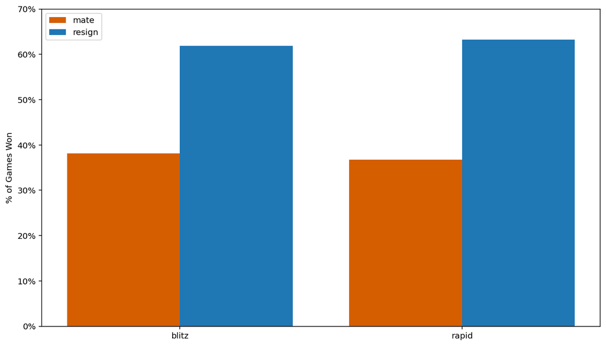

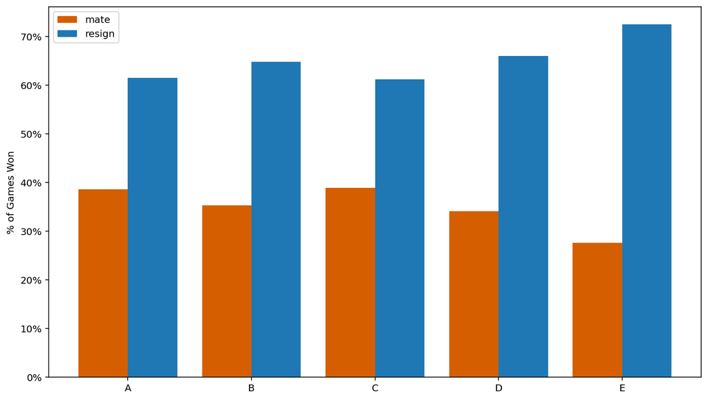

```python
def victory_percentages(var):
        ''' A function to plot the percentage of games won for each victory status, resign and mate,
            and its variation with a variable
            var: (string) the variable you want to plot the variation with.
        '''
        mate_counts = games.query('victory_status == "mate"').groupby(var)[var].count()
        resign_counts = games.query('victory_status == "resign"').groupby(var)[var].count()
        game_var_counts = games[var].value_counts()

        mate_var_pct= (mate_counts/game_var_counts)*100
        resign_var_pct= (resign_counts/game_var_counts)*100
        plt.figure(figsize=(12,7))

        plt.bar(data= games, x=mate_var_pct.index, height=mate_var_pct,
                width=-0.4, align='edge', color=sb.color_palette('colorblind')[3],label='mate');

        plt.bar(data= games, x=resign_var_pct.index, height=resign_var_pct,
                width=0.4, align='edge', label='resign');

        ticks= [0,10,20,30,40,50, 60, 70]
        labels = ['{}%'.format(t) for t in ticks]
        plt.yticks(ticks, labels);
        plt.ylabel('% of Games Won')
        plt.legend();

victory_percentages('game_rating')
victory_percentages('opening_eco')
```

- The trend is the same for both rapid rating and blitz rating games with resigning percentages are higher compared to checkmates in both.
- Resigning percentage in group E is the highest, but other than that all openings are having similar distribution.

### Talk about some of the relationships you observed in this part of the investigation. How did the feature(s) of interest vary with other features in the dataset?

There are a lot of factors that can possibly affect the features of interest and I will take the most interesting relationships one by one so it doesn't become so overwhelming.

- **Difference in rating** between players is the most obvious factor in **winning the game**; The players who win have higher rating, on average, than the opponent by around 80 rating points. Average absolute rating difference is higher at games that ends with checkmate compared to the games that ends with resigning; but it doesn't say if the one with higher rating wins or not which will be investigated later.
- Player as black is taking slightly more **number of turns**, on average, to win the game compared to player as white, and number of turns that needed to checkmate are,on average, higher significantly than that of resigning.
- White is **winning** with higher percentage whether by **checkmate or resigning** compared to black, but the difference is slightly higher at games that ends with checkmate.
- Victory status has low variation with variables like **game rating** and **opening ECO**, but as for winning, white is more dominant at blitz rating games than rapid rating ones and it also has higher percentage at all openings except for openings group E in which black has barely higher winning percentage with it.

### Did you observe any interesting relationships between the other features (not the main feature(s) of interest)?

- The two numerical variables; number of turns and difference in rating have a week negative correlation; the higher the difference in rating the fewer number of turns are needed to win the game.

## Multivariate Exploration

From what I have learned in the previous exploration, the variations of the variables of interest, winner and victory status, with rating difference and number of turns are significant, so I will start plotting the variables of interest one by one with these two variables.

```python
# making a sample of data to use for scatter plots
games_sample= games.sample(1000, replace=False, random_state=100)
```

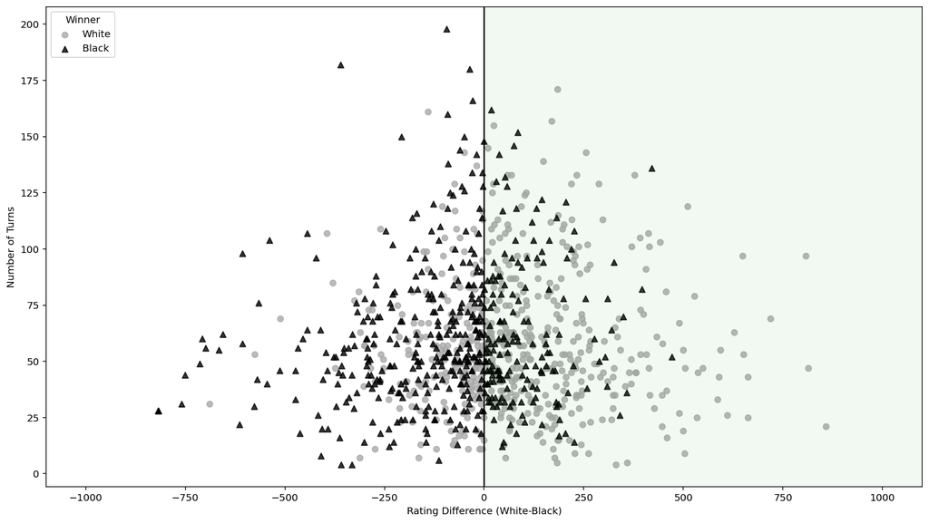

```python
# scatter plot of rating difference versus number of turns for each winner
winner_markers= [['white', 'o', 'darkgray'],
                ['black', '^', 'black']]

plt.figure(figsize=(16,9))
for winner, marker, color in winner_markers:
    sb.regplot(data = games_sample.loc[games_sample['winner']==winner], x = 'rating_diff_wb', y = 'turns',
               x_jitter=5,fit_reg = False, marker = marker, scatter_kws={'color':color});

plt.legend(title='Winner',labels=['White','Black']);
plt.axvspan(0, 1100, facecolor='g', alpha=0.05)
plt.axvline(0, color='k')
plt.xlim(-1100,1100)
plt.xlabel('Rating Difference (White-Black)')
plt.ylabel('Number of Turns');
```

This plot can clearly show what I learned earlier from the data and some interesting relationships.

- Most of the games are played between players of the **same or close rating** and lasted until about **40 to 70 turns**.
- Players, as white or as black, are **winning** more when their **ratings are higher** than their opponents compared to when they have less rating than their opponents.
- Games that are played with **high difference in rating** in the winner's favor tend to end in **less number of turns** than those with lower difference in rating.
- There are more players as **black winning** the game with **high number of turns** specially when the rating difference is small.

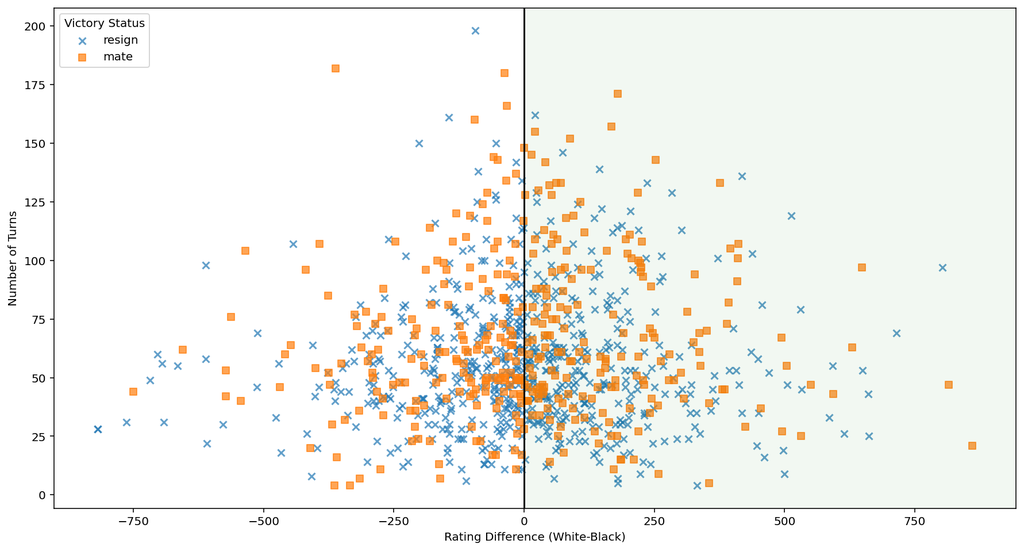

```python
# scatter plot of rating difference versus number of turns for each victory status
victory_markers= [['resign', 'x'],
                ['mate', 's']]

plt.figure(figsize=(15,8))
for victory, marker in victory_markers:
    ax=sb.regplot(data = games_sample.loc[games_sample['victory_status']==victory], x = 'rating_diff_wb', y = 'turns',
               fit_reg = False, marker = marker, scatter_kws={'alpha':0.7},);

plt.legend(title='Victory Status', labels=['resign','mate']);
plt.xlim(ax.get_xlim())
plt.axvspan(0,ax.get_xlim()[1], facecolor='g', alpha=0.05)
plt.axvline(0, color='k')
plt.xlabel('Rating Difference (White-Black)')
plt.ylabel('Number of Turns');
```

It is hard to interpret any findings in this visual as the distributions of games won by checkmate or resigning are similar.